# 10. 循环神经网络

Deep Learning I

10. 循环神经网络

WU Xiaokun 吴晓堃

xkun.wu [at] gmail

2022/04/29

# 序列模型

## 数据、结构

目前遇到的数据：表格、图像

- 图像数据：二维空间结构假设，用于**简化计算**

序列化数据：依赖某种**序关系**

- 文本：字（符）的先后顺序
- 视频、音频：时间顺序

序关系假设：先验知识，**预测**序列的后续

- 文本生成
- 股价、天气预测

## 序列数据：难点

**季节性**统计规律：年后、毕业季的就业率，“新增高素质人才”

预测明天比预测过去更难：特别是股价，先见之明比事后解释难得多

- **外推法**、内插法

**顺序重排**导致意义丢失：文本、音乐、视频、语音

**情感分析**：例如影评，大众对电影的看法随时间推移而变化

## 情感分析：心理学提示

**锚定效应**：基于他人的意见做评价，“人云亦云”

- 电影得奖后关注度、评分骤升，持续到大众忘记这个奖项

**享乐效应**：适应较高（低）水平的电影并认为是常态，“拉高（低）了审美”

- 看过大量精彩电影之后，对其他电影的评分降低

其他相关因素

- 季节性：很少观众在暑假看贺岁片
- 道德高地：导演、演员的不当行为导致评分稍低

## 统计建模

将观测看成随机变量：时间$t$观测到$x_t$

- **序列化随机变量**的分布：$x_1,..,x_T \sim p(x_1,..,x_T) \equiv p(\mathbf{x})$

注意：序列化随机变量一般**不是相互独立**的；此处省略了模型参数

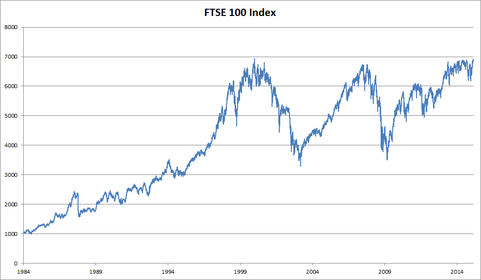

**外推预测**：$x_t \sim p(x_t | x_{t-1},..,x_1) \equiv p(x_t | x_{1:t-1})$

## 统计建模：联合、条件概率

联合、条件概率公式

$$\begin{aligned}
P(x_1, x_2, .., x_T) &=
P(x_1)P(x_2|x_1)P(x_3|x_{1:2})...P(x_T|x_{1:T-1}) \\
&= \prod_{k=1}^T P(x_k|x_{1:k-1}) \\
\end{aligned}$$

逆序也可计算，但物理上不一定能够解释

$$\begin{aligned}
P(x_1, x_2, .., x_T) &=
P(x_T)P(x_{T-1}|x_{T})P(x_{T-2}|x_{T-1:T})...P(x_1|x_{2:T}) \\
\end{aligned}$$

## 自回归模型

外推预测：$x_t \sim p(x_t | x_{1:t-1})$

- **自回归模型**：对见过的数据建模、对自己执行回归，即自监督学习

$$x_t \sim p(x_t | x_{1:t-1}) \equiv p(x_t | f(x_{1:t-1}))$$

Markov 假设：当前预测只取决于之前**最近的$\tau$个观测**

- $\hat{x}_t \sim p(x_t | x_{t-\tau:t-1}) \equiv p(x_t | f(x_{t-\tau:t-1}))$

## 隐变量自回归模型

外推预测：$x_t \sim p(x_t | x_{1:t-1})$

- **隐变量自回归模型**：当前隐状态整合过去所有的观测信息

$$\begin{aligned}
\hat{x}_t &= p(x_t | h_t)\\
h_t &= g(x_{t-1}, h_{t-1})\\
\end{aligned}$$

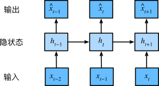

## 实验：序列模型

## 小结：序列模型

- 序列模型：当前预测与之前的观测数据相关
  - Markov假设：当前预测只取决于之前的最近几个观测数据
- 自回归模型：使用自身历史数据建模
- 隐变量模型：使用隐状态整合过去所有的观测信息

# 文本预处理

## 常见预处理步骤

- 将文本作为**字符串**加载到内存中。
- 将字符串拆分为**词元**（如单词、字符）。
- 建立一个**词表**，将拆分的**词元映射**到数字索引。
- 将文本转换为数字索引**（向量）序列**，方便模型操作。

## 实验：文本预处理

# 语言模型和数据集

## 语言模型

**语言模型 language models (LMs)**：对序列（中的词）赋予概率

- $P(W) = P(w_1, w_2, .., w_n)$
- $P(w_n | w_1, w_2, .., w_{n-1})$

有时也称为**语法、文法**

**N元语法 n-gram**：连续N个词看作一个单元

- **二元语法 2-gram/bigram**：“your homework”，“我们”

## N元语法：近似计算

本质是近似计算：

- **用最近的 N 个词替代**观察到的全部字符信息

例如**二元语法 bigram**：$P(w_n|w_{1:n-1}) \approx P(w_n|w_{n-1})$

$$\begin{aligned}
P(他下课后去了食堂) &= P(他下课后去了)P(食堂|他下课后去了) \\
&\approx P(他下课后去了)P(食堂|去了) \\
&\approx P(他)P(下课后|他)P(去了|下课后)P(食堂|去了) \\
\end{aligned}$$

**Markov 假设**：当前状态只取决于最近 N 个单元的信息

- **Markov 模型**：预测时不关注过于久远的历史信息

## 特殊情况

**二元语法 bigram**：“活在当下”

- 每个词只取决于前面的一个词

$$P(w_{1:n}) \approx \prod_{k=1}^n P(w_k|w_{k-1}) \\$$

**一元语法 unigram**：随机行走

- 没有约束条件，每个词独立计算概率

$$P(w_{1:n}) \approx \prod_{k=1}^n P(w_k) \\$$

## 一般情况：N元语法

$$\begin{aligned}
P(w_n|w_{1:n-1}) &\approx P(w_n|w_{n-N+1:n-1}) \\
P(w_{1:n}) &\approx \prod_{k=1}^n P(w_k|w_{k-N+1}) \\
\end{aligned}$$

N元语法简单、易理解；但用于语言建模**通常不足**

- 语言中**长距离依赖**对语义理解很重要

> 虽然**一切可能性的总和**的这一理念，就该总和作为条件是任何一个事物普遍的规定的基础而言，在可能构成该总和的种种谓词方面本身还是未被规定的，而且我们由此所思维的，在根本上无非就是一切可能的谓词的总和，然而，我们在更仔细的研究中毕竟发现，这个理念作为元始概念排除了一大堆作为通过别的谓词引申出来的而已经被给予的、或者与其他谓词不能共存的谓词；它把自己提炼为一个普遍先天地被规定的概念，并由此成为一个单一的对象的概念，这个对象通过纯然的理念完全地被规定，从而必须被称为纯粹理性的**理想**。  
> –《纯粹理性批判》，康德

## 最大似然估计

**最大似然估计 Maximum Likelihood Estimation (MLE)**

- 解决的问题：事件的可能性有多大？
  - 给定观测结果：统计出现的**频率**即可
- 从语料库统计N元词频，然后正则化为**可能性**

例如二元语法：

$$P(w_n|w_{n-1}) = \frac{\Gamma(w_{n-1}w_n)}{\sum_w \Gamma(w_{n-1}w)} =
\frac{\Gamma(w_{n-1}w_n)}{\Gamma(w_{n-1})}\\$$

## 加一平滑

也称 **Laplace平滑**：灵感来源于（热）扩散过程

- （假装）每个词汇序列看到过比实际值多一次：所有词计数加一

例如一元语法：$w_i \in w_{1:N}$，序列$W = w_{1:N}$有$N$个词

$$\begin{aligned}
P_{MLE}(w_i) &= \frac{c_i}{N}\\
P_{Add-1}(w_i) &= \frac{c_i + 1}{N + |V|}
\end{aligned}$$

- 注意：分母需要对应增加总共$|V|$个词汇

## N元模型词频比较

都遵循**Zipf定律**：$n_i \propto \frac{1}{i^\alpha}$

- **双对数空间**上近似直线：$\log n_i = - \alpha \log i + c$

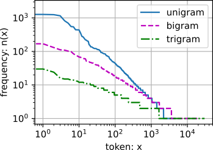

- 词表中N元组数量并不多，却可以表述非常复杂的语句
  - 说明语言中存在大量**结构**，可应用模型提取模式
- 很多N元组频率非常低：似然估计 + **平滑处理（如加一）不适合语言模型**
  - 信息非常稀疏：直接改公式对统计规律的破坏过于严重

推论：需要深度神经网络模型学习语言内在规律

## 构造序列化数据集

序列太长、在线应用：拆分成**相同时间步**的子序列方便模型读取

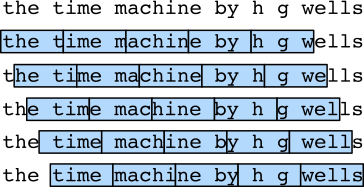

- 预测词元：真实标签对应原序列中**下一个位置**
- 起始位置：随机偏移量
- 采样策略：随机（生成文本更多变化）、顺序（生成文本更连贯）

## 实验：语言模型和数据集

## 小结：语言模型和数据集

- 语言模型：预测句子或下一词的概率
  - 联合或条件概率
- N元语法：连续N个词看作一个单元
  - Markov假设

# 循环神经网络

## 回顾：自回归模型

N元语法（Markov假设）：当前预测取决于前N个观测

- 长距离依赖？必须增加N（回忆德语例子）
  - 参数量呈**指数增长**：词表存储$|V|^N$，例如$8000^{100}$？

隐变量：（仅）**整合**到目前为止观测到的所有数据信息

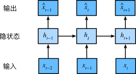

- 时间步$t$的更新：$h_t = f(x_{t-1}, h_{t-1})$

## 回顾：单隐藏层的MLP

隐藏层参数：提取特征，即对数据“不同角度的描述”

- 可学习、固定公式、自动计算：自动微分 + 梯度下降

$$\begin{aligned}
\textbf{H} &= \sigma(\textbf{X} \textbf{W}^h + \textbf{b}^h)\\
\textbf{O} &= \textbf{H} \textbf{W}^o + \textbf{b}^o\\
\end{aligned}$$

- $\textbf{X} \in \mathbb{R}^{B \times d}, \textbf{W}^h \in \mathbb{R}^{d \times l}, \textbf{b}^h \in \mathbb{R}^{1 \times l}$
- $\textbf{H} \in \mathbb{R}^{B \times l}, \textbf{W}^o \in \mathbb{R}^{l \times C}, \textbf{b}^o \in \mathbb{R}^{1 \times C}$

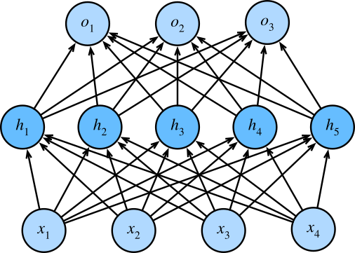

注意：不是隐变量，没有按时间步“阶段性整合信息”

## 基于循环神经网络的字符级语言模型

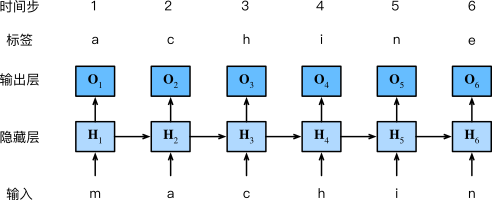

- 预测下一个词元：将原始序列移位一个词元作为标签

## 循环神经网络：时间步、隐变量

时间步$t$的更新：$h_t = f(x_{t-1}, h_{t-1})$

$$\begin{aligned}
\textbf{H}_t &= \sigma(\textbf{X}_t \textbf{W}_x^h +
\textbf{H}_{t-1} \textbf{W}_h^h + \textbf{b}^h)\\
\textbf{O}_t &= \textbf{H}_t \textbf{W}_h^o + \textbf{b}^o\\
\end{aligned}$$

- $\textbf{X}_t \in \mathbb{R}^{B \times d}$：时间步$t$的小批量样本
- $\textbf{H}_t \in \mathbb{R}^{B \times l}$：时间步$t$的隐变量
- $\textbf{W}_h^h \in \mathbb{R}^{l \times l}$：时间步之间隐变量的更新

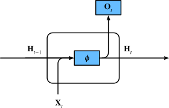

注意：不同时间步使用**相同参数**$\textbf{W}_x^h, \textbf{W}_h^h, \textbf{W}_h^o, b^h, b^o$

- 参数量不会随时间推移而增长，计算开销恒定
- “循环”：隐变量的当前时间步定义$\textbf{H}_t$与前一时间步定义$\textbf{H}_{t-1}$**模式相同**

## 循环神经网络：架构

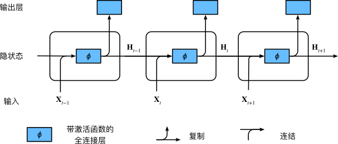

## 实验：循环神经网络

隐状态中$\textbf{X}_t \textbf{W}_x^h + \textbf{H}_{t-1} \textbf{W}_h^h$

```python
X, W_xh = torch.normal(0, 1, (3, 1)), torch.normal(0, 1, (1, 4))
H, W_hh = torch.normal(0, 1, (3, 4)), torch.normal(0, 1, (4, 4))
torch.matmul(X, W_xh) + torch.matmul(H, W_hh)
```

```
tensor([[-0.5702, -0.4673, -0.1508, -0.0185],
        [-1.3559,  0.8042, -1.4394, -3.1735],
        [ 0.6559,  1.3140,  0.2949,  0.0781]])
```

等价于$\textbf{X}_t$和$\textbf{H}_{t-1}$拼接与$\textbf{W}_x^h$和$\textbf{W}_h^h$**拼接的矩阵乘法**：并行计算

```python
torch.matmul(torch.cat((X, H), 1), torch.cat((W_xh, W_hh), 0))
```

```
tensor([[-0.5702, -0.4673, -0.1508, -0.0185],
        [-1.3559,  0.8042, -1.4394, -3.1735],
        [ 0.6559,  1.3140,  0.2949,  0.0781]])
```

## 困惑度

**困惑度 perplexity (PP)**：模型在测试集上算得概率的倒数，再由词数归一化

$$\begin{aligned}
PP(W) &= P(w_1 w_2 .. w_N)^{-\frac{1}{N}} \\
&= \sqrt[N]{\frac{1}{P(w_1 w_2 .. w_N)}} = \sqrt[N]{\prod_{k=1}^N
\frac{1}{P(w_k|w_{1:k-1})}} \\
\end{aligned}$$

- 实际计算：$\exp(\log PP(W)) = \exp \left( - \frac{1}{N} \sum \log P(w_k|w_{1:k-1}) \right)$

信息论中**平均交叉熵**：$- \frac{1}{N} \sum \log P(w_k|w_{1:k-1})$

- 何为准确预测？压缩序列容易、存储开销低

## 困惑度：案例

**困惑度 perplexity (PP)**：模型在测试集上算得概率的倒数，再由词数归一化

$$\begin{aligned}
PP(W) &= P(w_1 w_2 .. w_N)^{-\frac{1}{N}} \\
&= \sqrt[N]{\frac{1}{P(w_1 w_2 .. w_N)}} = \sqrt[N]{\prod_{k=1}^N
\frac{1}{P(w_k|w_{1:k-1})}} \\
\end{aligned}$$

下一位置可能出现的词数（即**分支因子**）的加权组合

- 完美预测：$PP = 1$
- 0命中：$PP = \infty$
- 基准：所有可用词元上等概率分布，PP = 词目数
  - 无压缩存储序列：等概率情况下的最优编码方式
  - 可以看成**实践上限**：经过设计的模型理应超过随机猜测（类比抛硬币）

## RNN：应用

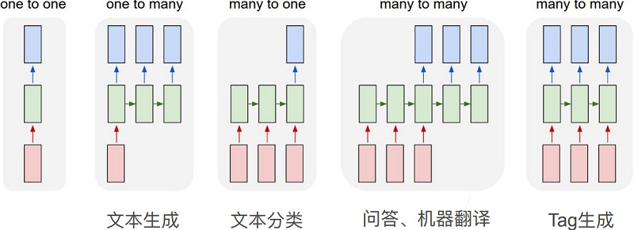

## 小结：循环神经网络

- RNN：输出取决于当前输入、前一隐变量
- 语言模型应用：根据当前词预测下一时间步
- 困惑度：度量语言模型，加权的分支因子

# 实验：循环神经网络的从零开始实现

## 独热编码

将词元编码为相互独立的单位向量

## 预热

文本生成任务有时给定一小段“预热字串”

- 例如：“我永远不能忘记……”
- 可以用于优化模型参数，但不需要输出预测
  - 预热：**有监督的初始化**，获得更好的参数初始值

## 梯度剪裁

对长度$T$的序列：反向传播产生$O(T)$的矩阵乘法链

- 数值不稳定：梯度爆炸、消失

**Lipschitz 假设**：$|f(\mathbf{x}_1) - f(\mathbf{x}_2)| \le L \lVert \mathbf{x}_1 - \mathbf{x}_2 \rVert$

- 梯度更新：$|f(\mathbf{x}) - f(\mathbf{x} - \mathbf{g} \eta)| \le L \eta \lVert \mathbf{g} \rVert$
  - 限制学习率：限制优化进展、数值问题

**梯度剪裁**：限制梯度，即$\mathbf{g} \leftarrow \min\left(1, \frac{\theta}{\|\mathbf{g}\|}\right) \mathbf{g}$

- 可以防止梯度爆炸，但不能应对梯度消失

# 实验：循环神经网络的简洁实现

# Review

## 本章内容

序列模型。语言模型。循环神经网络。

**重点**：序列模型、自回归模型、隐变量模型；N元语法、最大似然估计、平滑处理；序列化数据集的构造；循环神经网络的架构，及其预测、评测、应用方法。

**难点**：困惑度的原理；循环神经网络的实现。

## 学习目标

- 理解序列模型、自回归模型、隐变量模型
- 理解N元语法、最大似然估计、平滑处理
- 理解序列化数据集的构造方法
- 理解循环神经网络的架构，及其预测、评测、应用方法

## 问题

简述序列模型、自回归模型、隐变量模型的建模方法。

简述N元语法、最大似然估计、平滑处理的原理。

简述序列化数据集的构造方法。

简述循环神经网络的架构，及其预测、评测、应用方法。